# Progetto Laboratorio di Statistica

Analisi delle vendite al dettaglio nel settore abbigliamento (FRED)

Amerigo Ciriello

2026-10-07

# 1. Introduzione

In questo report analizziamo la serie storica delle vendite al dettaglio dei negozi di abbigliamento negli Stati Uniti. L’obiettivo è applicare i principali strumenti di analisi delle serie temporali studiati nel corso: analisi esplorativa, individuazione di outlier, decomposizione, trasformazioni, regressione e metodi di previsione.

### 1.1 Analisi strutturale

I dati provengono dalla *Monthly Retail Trade Survey - MRTS* e fornisce stime mensili sul valore in dollari delle vendite al dettaglio ma anche dei servizi di ristorazione e delle scorte di magazzino. La partecipazione al sondaggio è volontaria ed è autorizzata dal *Title 13 United States code*. Il campionamento avviene dal 1951 e viene rinnovato (aggiornamento strutturale) ogni 5 anni. Coinvolge circa 13.000 aziende di vendita al dettaglio con dipendenti retribuiti. Esse vengono stratificate in base al fatturato e al tipo di attività principale. Circa 2.500 delle 13.000 vengono selezionate con certezza, le restanti vengono selezionate casualmente.

**Descrizione Completa:** https://www.census.gov/retail/mrts/about_the_surveys.html

**Link alla serie storica:**(codice `MRTSSM4481USN`) https://fred.stlouisfed.org/series/MRTSSM4481USN

**Periodo Analizzato:** *gennaio 1992 – ultima data disponibile*

**Frequenza:** *mensile*

**Unità di misura:** *milioni di dollari*

**Tipo di dato:** *grezzi (non destagionalizzati)*

```
## Rows: 411
## Columns: 2
## $ observation_date <date> 1992-01-01, 1992-02-01, 1992-03-01, 1992-04-01, 1992…
## $ MRTSSM4481USN    <dbl> 4727, 5032, 5882, 6529, 6610, 6382, 6391, 7307, 6713,…
```

```
##   observation_date MRTSSM4481USN
## 1       1992-01-01          4727
## 2       1992-02-01          5032
## 3       1992-03-01          5882
## 4       1992-04-01          6529
## 5       1992-05-01          6610
## 6       1992-06-01          6382
```

Abbiamo un numero di osservazioni pari a 411. Mediante un *glimpse* dei dati possiamo notare che: *observation_date* è formattato come data e *MRTSSM4481USN* formattato come numero decimale.

# 2. Analisi esplorativa

La seguente analisi esplorativa è eseguita su dati grezzi.

### 2.1 Analisi esplorativa generale

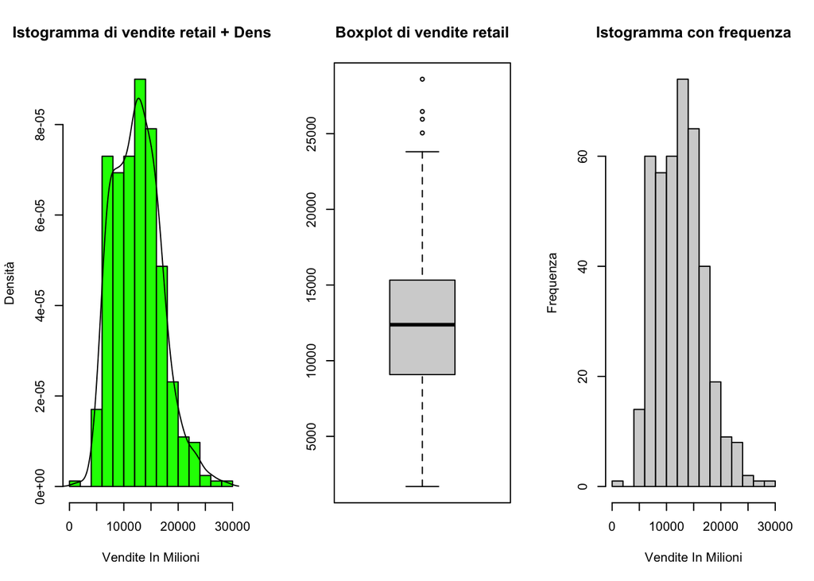

```
##    vars   n    mean     sd median  trimmed     mad  min   max range skew
## X1    1 411 12480.7 4356.8  12378 12238.68 4587.16 1690 28598 26908 0.51
##    kurtosis     se
## X1     0.21 214.91
```

La distribuzione presenta una tendenza centrale dato che la media pari a $12480.7$ e la mediana pari a $12378$ sono molto vicine tra loro. Il range è molto ampio e pari a $26908$. La deviazione standard è pari a $4356.8$. La distribuzione presenta una live asimmetria positiva pari a $0.51$ e una kurtosi pari a $0.21$.

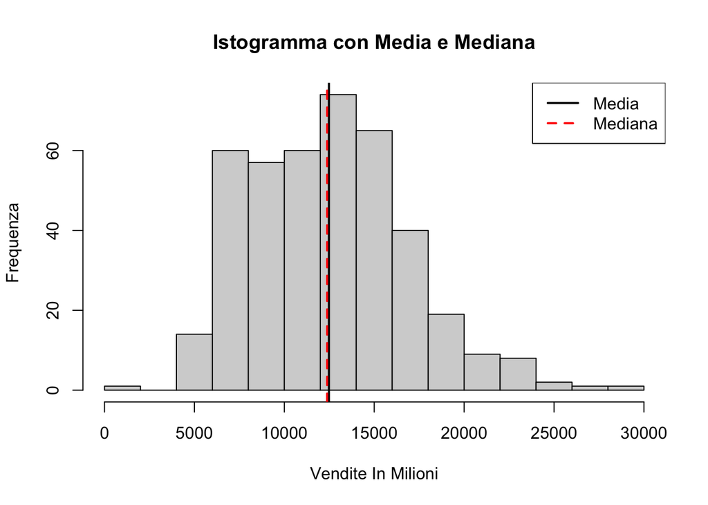

### 2.2 Dati mancanti

```r
statsNA(Vendite_Retail_USA)
```

```
## [1] "Length of time series:"
## [1] 411
## [1] "-------------------------"
## [1] "Number of Missing Values:"
## [1] 0
## [1] "-------------------------"
## [1] "Percentage of Missing Values:"
## [1] "0%"
## [1] "-------------------------"
## [1] "Number of Gaps:"
## [1] 0
## [1] "-------------------------"
## [1] "Average Gap Size:"
## [1] 0
## [1] "-------------------------"
## [1] "No NAs in the time series."
## [1] "-------------------------"
```

```
## [1] "There are no NAs in the time series"
```

Non essendovi dati mancanti non è necessario effettuare alcun processo di imputazione.

### 2.3 Time plot

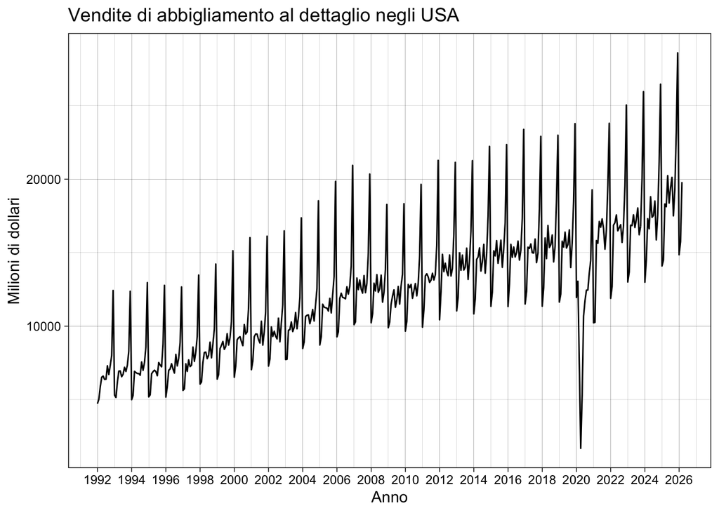

[interactive chart not shown]

La serie presenta un trend crescente sul lungo periodo, una forte stagionalità con picco regolare a dicembre e minimo a inizio anno. Essendo quindi a cadenza fissa annuale, le oscillazioni non costituiscono una componente ciclica. L’ampiezza dei picchi cresce con il livello della serie il che ci suggerisce la presenza di eteroschedasticità. Abbiamo un evidente crollo nel 2020 (coincide con il lockdown COVID), molto meno evidente è il crollo dovuto alla crisi dei mutui subprime del 2008.

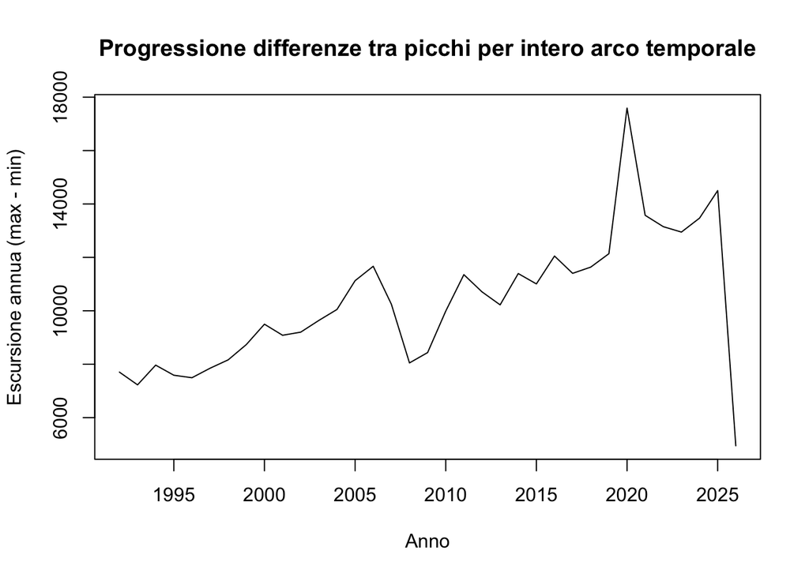

Il grafico dell’ escursione annua (differenze tra picchi ) ci suggerisce la presenza di una struttura di eteroschedasticità moltiplicativa (Da verificare). La varianza non è costante nel tempo e l’ampiezza delle fluttuazioni stagionali cresce proporzionalmente al livello della serie.

### 2.4 Identificazione preliminare degli Outlier

```r
tsoutliers(Vendite_Retail_USA)
```

```
## $index
##  [1] 180 204 207 216 323 329 330 331 332 334 335 336 337 338 339 340 341 342 343
## [20] 344 347 348 350 351 352 353 354 355 359 364 407 408
##
## $replacements
##  [1] 19450.37 19264.79 12534.54 19016.91 17924.85 16616.26 14951.42 15502.44
##  [9] 15713.89 14779.54 17256.77 22286.97 10548.43 11518.82 14828.86 13604.21
## [17] 15018.11 13305.65 13963.69 14113.08 16490.38 21869.49 11633.33 15420.37
## [25] 14536.15 16398.69 15070.30 16105.24 18928.84 15796.51 21967.90 27154.33
```

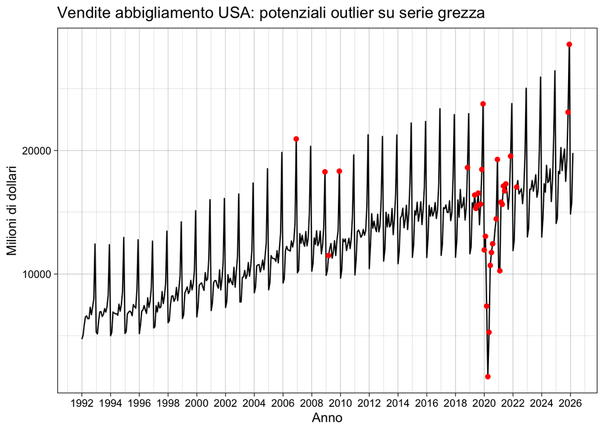

Alcuni periodi vengono segnalati come anomali: la crisi finanziaria del 2008-2009, il blocco del 2020 legato al COVID e infine alcuni valori negli ultimi anni della serie. Parte di queste segnalazioni potrebbe essere frutto dell’eteroschedasticità. Dove le oscillazioni sono più ampie la funzione le marca come osservazioni insolite, anche quando non lo sono realmente. La decisione di rimuovere o meno un outlier non è automatica e dipende da due fattori: la natura del valore e l’obiettivo dell’analisi. Un’osservazione frutto di errore di misura va corretta o rimossa mentre una osservazione eccezionale (come il COVID) va trattata in base a ciò che si intende studiare.

### 2.5 Analisi della stagionalità

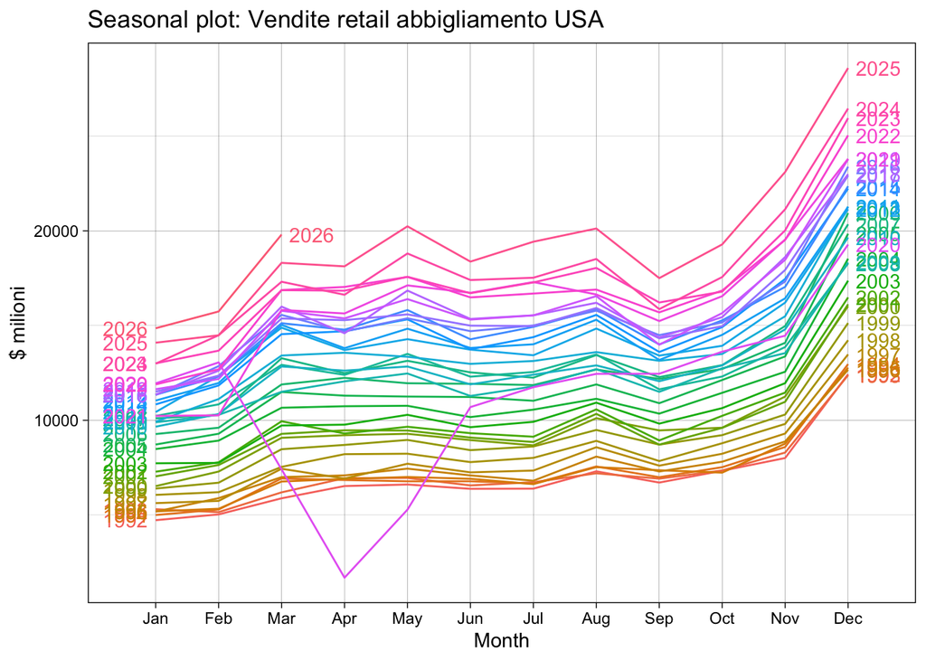

L’analisi del grafico stagionale mostra la presenza di un trend crescente nel lungo periodo, dovuto probabilmente all’ espansione del settore del fast fashion oppure a cambiamenti nelle dinamiche dei consumi.C’è un pattern chiaro che si ripete a dicembre, le vendite si mantengono stabili per tutto l’anno per poi “impennarsi” a fine anno. Il 2020 si distingue chiaramente con un drastico crollo delle vendite ad aprile.

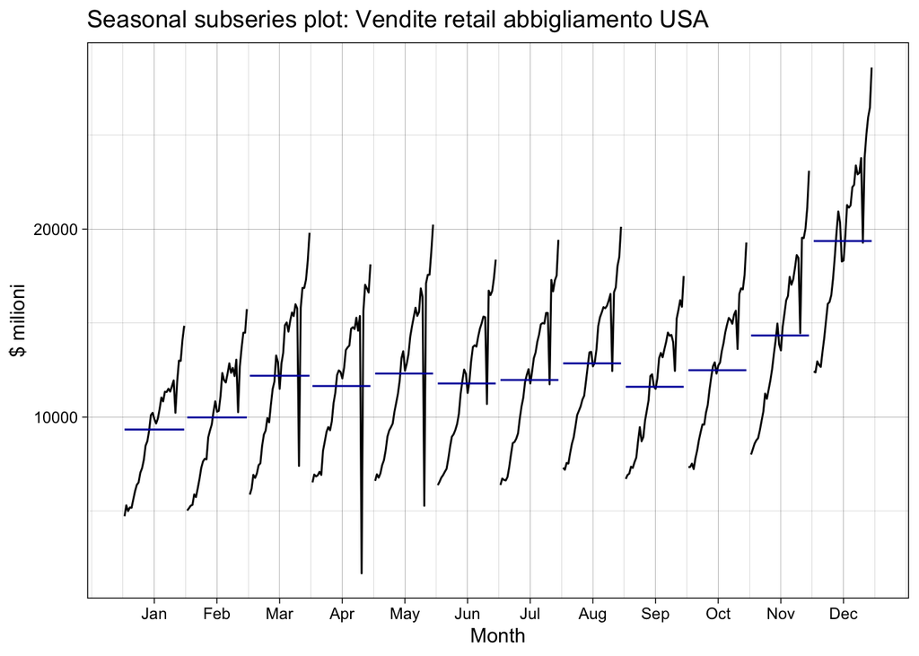

### 2.6 Autocorrelazione (ACF su dati grezzi)

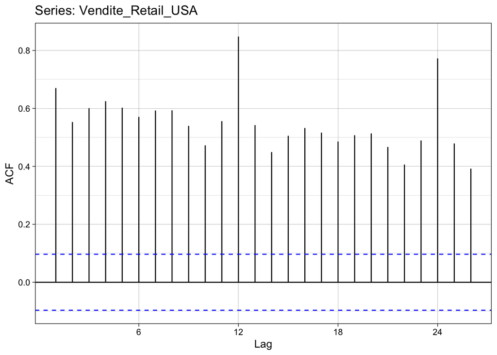

Il correlogramma ci dice che la serie è non stazionaria e non compatibile con un processo white noise. Tutte le autocorrelazioni risultano significative (oltre i limiti di confidenza) e decrescono molto lentamente all’aumentare del lag, ciò indica presenza di trend. Si osservano inoltre picchi marcati ai lag 12 e 24, corrispondenti ai cicli annuali dei dati mensili, che segnalano una forte componente stagionale con ricorrenza regolare di anno in anno. La struttura evidenziata dall’ACF motiva l’applicazione di trasformazioni per stabilizzare varianza, detrendizzare e destagionalizzare.

# 3. Trasformazione, decomposizione e differenziazione

### 3.1 Aggiustamento rispetto all’ inflazione

Dato che nelle serie storiche economico-finanziare i valori nominali non sono direttamente confrontabili nel tempo poichè il potere d’acquisto cambia a causa di fattori (Esempio: inflazione), è necessario aggiustare i valori correggendoli per CPI (Consumer Price Index). La conversione avviene in questo modo:
$$x_t =
\frac{y_t}{z_t} \times CPI_{base}$$

dove ${y_t}$ è il valore nominale al tempo $t$, ${z_t}$ è l’indice dei prezzi (CPI) al tempo $t$ e $CPI_{base}$ è il CPI dell’ultimo mese disponibile. La serie reale è così espressa a **prezzi correnti**: i valori sono confrontabili nel tempo e interpretabili come dollari di oggi.

```r
CPI <- read.csv("CPIAUCNS.csv")
cpi_full <- CPI[CPI$observation_date >= "1992-01-01", ]
cpi_ts <- ts(cpi_full$CPIAUCNS, start = c(1992, 1), frequency = 12)
finestra <- ts.intersect(Vendite_Retail_USA, cpi_ts)
cpi_base <- tail(as.numeric(finestra[, "cpi_ts"]), 1)   # CPI dell'ultimo mese = prezzi correnti
Vendite_Reali_CPI <- (finestra[, "Vendite_Retail_USA"] / finestra[, "cpi_ts"]) * cpi_base
```

Controlliamo che la serie corretta per CPI non abbia dati mancanti

```
## [1] "Length of time series:"
## [1] 411
## [1] "-------------------------"
## [1] "Number of Missing Values:"
## [1] 1
## [1] "-------------------------"
## [1] "Percentage of Missing Values:"
## [1] "0.243%"
## [1] "-------------------------"
## [1] "Number of Gaps:"
## [1] 1
## [1] "-------------------------"
## [1] "Average Gap Size:"
## [1] 1
## [1] "-------------------------"
```

[output cut: 17 more lines]

Dato che presenta 1 NA possiamo procedere ad applicare un metodo di imputazione basato su Interpolazione lineare.

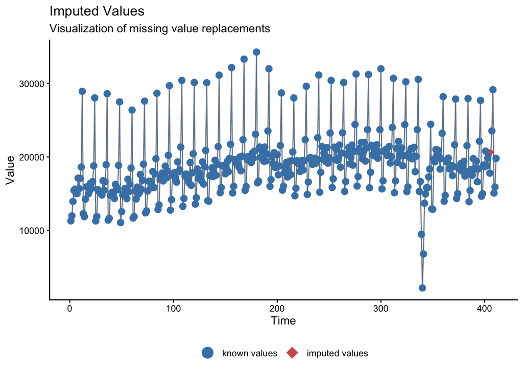

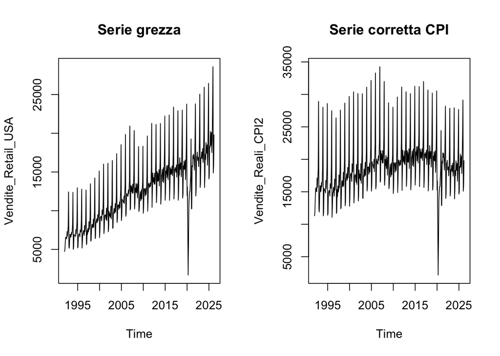

Il confronto tra le serie (nominale vs corretta per CPI) rivela un aspetto interessante. Sui valori nominali il trend è crescente, le vendite sembrano aumentare ininterrottamente dal 1992 a oggi. Dopo la correzione per inflazione,però, la serie reale mostra una crescita sostenuta fino alla metà degli anni 2000, seguita da una lunga fase di sostanziale stagnazione — i volumi reali restano grosso modo fermi per più di 10 anni, c’è una ripresa solo dopo lo shock del Covid. Gran parte dell’incremento nominale registrato negli ultimi vent’anni era quindi attribuibile all’aumento dei prezzi e non a una reale espansione delle quantità vendute.

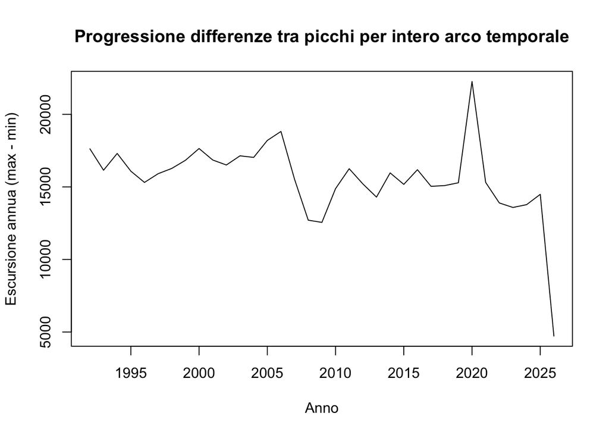

La cosa interessante che eviciamo è che l’escursione annua calcolata sulla serie corretta per CPI non mostra alcuna tendenza crescente, si mantiene attorno a una banda stabile. Questo ci suggerisce che una applicare una trasformazione alla serie per stabilizzarne la varianza potrebbe non servire,una volta depurata dall’inflazione, l’ampiezza delle oscillazioni stagionali non dipende più dal livello della serie. Le uniche due deviazioni sono interpretabili 2008-2009 riconferma la crisi dei mutui subprime, il picco isolato del 2020 riflette il Covid. Essendo il 2026 non concluso, le differenze non sono ancora interpretabili e quindi possiamo tralasciarle. Ne concludiamo che l’eteroschedasticità osservata sui dati nominali era dunque in larga parte un artefatto dei prezzi e che probabilmente non servirà applicare alcun tipo di trasformazione (Ne segue verifica).

### 3.2 Trasformata Box-Cox

```r
lambda<-BoxCox.lambda(Vendite_Reali_CPI2,method = "loglik")
lambda
```

```
## [1] 1.7
```

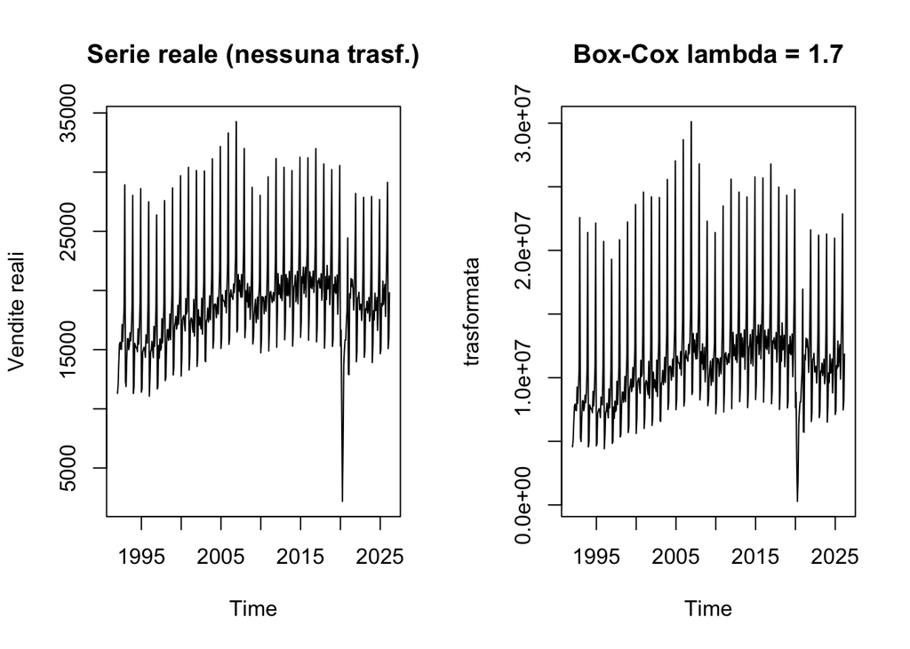

La stima con il metodo della massima verosimiglianza restituisce $\lambda \approx 1.7$, un valore che suggerirebbe una trasformazione di potenza. Tuttavia mediante il confronto grafico, possiamo dedurre che non è necessaria. I pannelli mostrano che la serie trasformata è strutturalmente identica a quella reale cambia solo la scala dei valori,non riduce l’ampiezza delle oscillazioni né stabilizza ulteriormente la varianza. Una volta rimossa l’inflazione, l’ampiezza delle fluttuazioni stagionali non dipende più dal livello della serie. Applicare Box-Cox introdurrebbe solo una ulteriore distorsione di scala.Lavoriamo quindi sulla serie reale non trasformata.

### 3.3 Decomposizione

La decomposizione scompone la serie nelle sue componenti strutturali. Secondo lo schema additivo le componenti sono date da $y_t = T_t + S_t + R_t$ , dove $T_t$ è il trend-ciclo, $S_t$ è la componente stagionale e $Rt$ il residuo. Dato che stiamo lavorando sulla serie corretta per inflazione, in base a quanto osservato, possiamo escludere le decomposizione moltiplicativa poichè l’ampiezza delle variazioni stagionali è costante nel tempo indipendentemente dal livello della serie. Successivamente applicheremo le decomposizioni X11, X13 SEATS ed infine la STL robusta.

#### 3.3.1 Decomposizione additiva classica

La decomposizione additiva classica si basa sulle medie mobili che permettono di smussare le fluttuazioni casuali mettendo in evidenza il trend. Dato che il periodo stagionale è pari possiamo usare una media mobile pesata di ordine $m+1$. Sia *MA: Moving Average* useremo una *2x12MA*

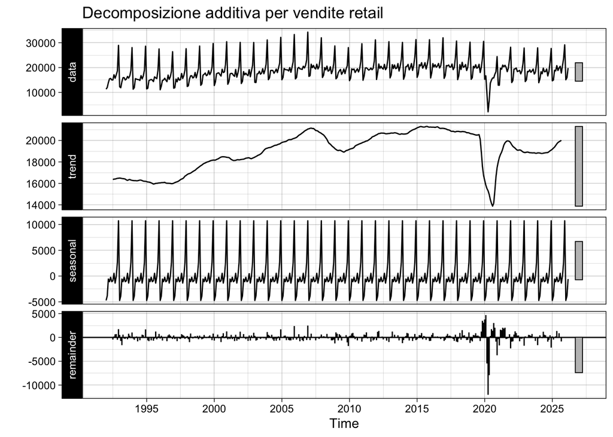

La cosa interessante da notare è che il residuo è piccolo e senza struttura per quasi tutto il periodo, tranne per un’esplosione nel 2020. Questo è il limite della decomposizione classica.Il Covid non viene assorbito dal trend ma si riversa tutto nel residuo, inoltre guardando il pannello del trend abbiamo comunque distorto la stima di esso.

#### 3.3.2 Decomposizione X11

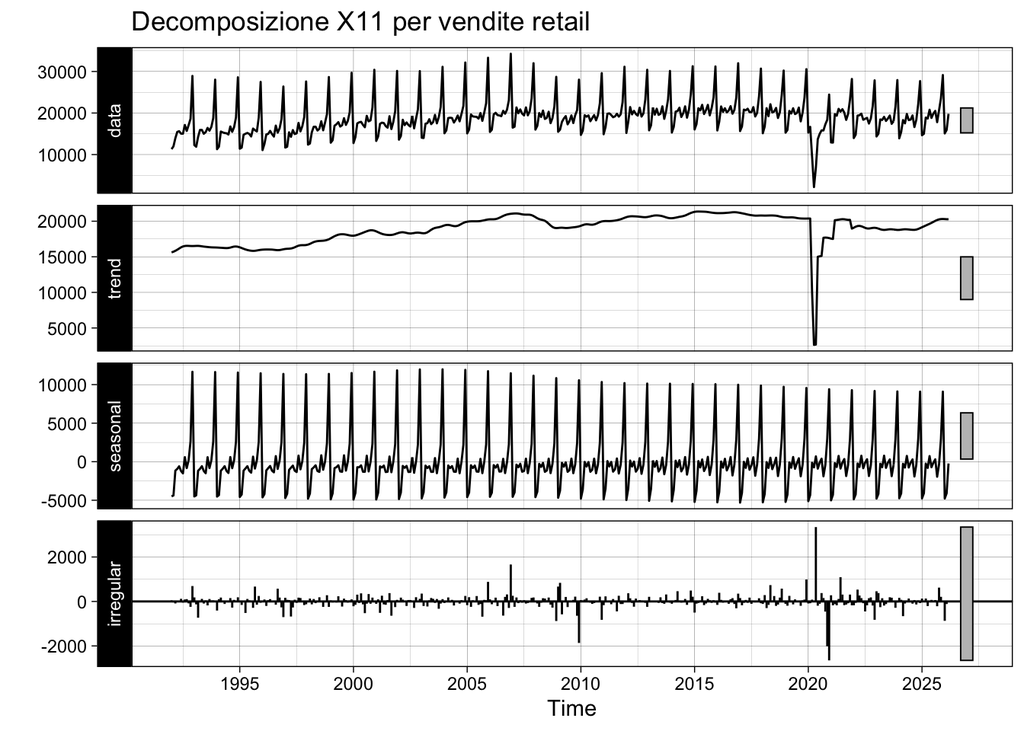

La X11 incorpora il crollo del 2020 nel trend senza isolarlo nel residuo distorcendo di conseguenza la stima del trend.

#### 3.3.3 Decomposizione X13 SEATS

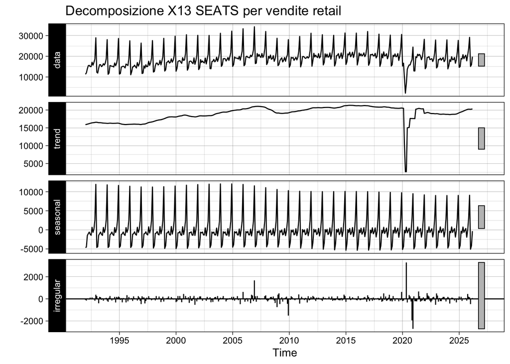

Analogo ala X11 i metodi risultano equivalenti.

#### 3.3.4 Decomposizione STL robusta

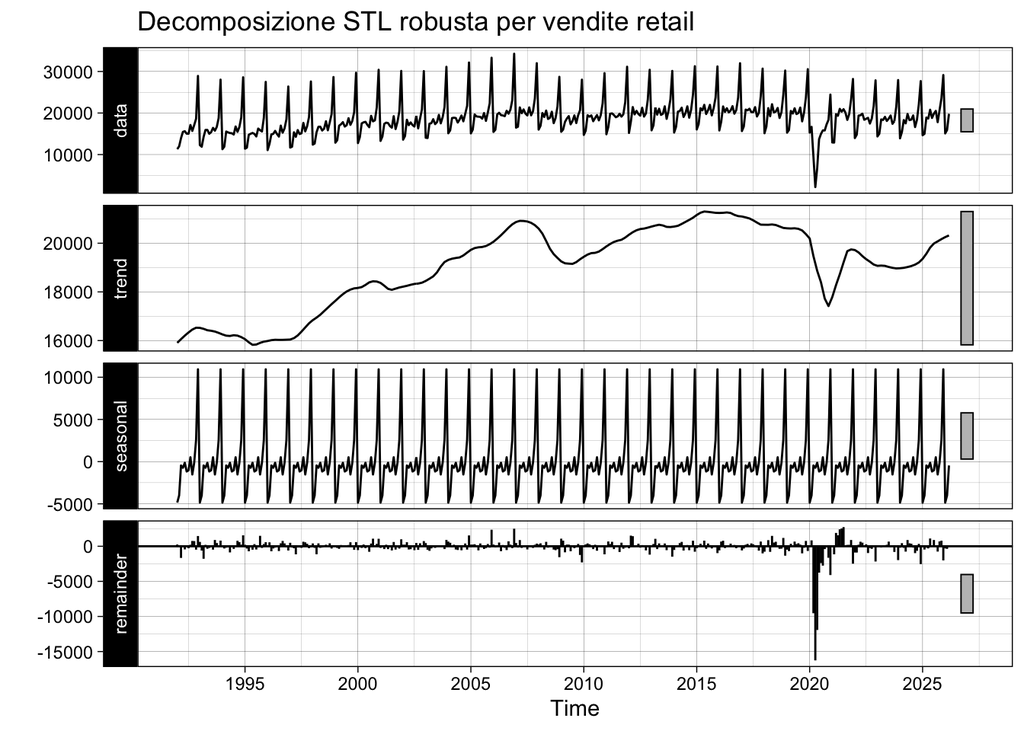

STL riesce a riconoscere il 2020 come un’anomalia, mantiene il trend abbastanza liscio e riversa tutto nel residuo.

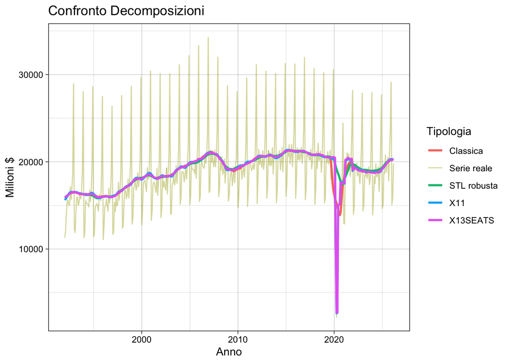

### 3.4 Outlier riesame

```r
R_t <- stl.fit$time.series[, "remainder"]
tsoutliers(R_t)
```

```
## $index
##  [1] 180 339 340 341 342 344 348 353 354 355
##
## $replacements
##  [1]   522.0169   801.4231  -258.9387  -785.1617 -1709.3750 -1445.7628
##  [7] -2688.5007  1603.9016  1085.7625   898.7446
```

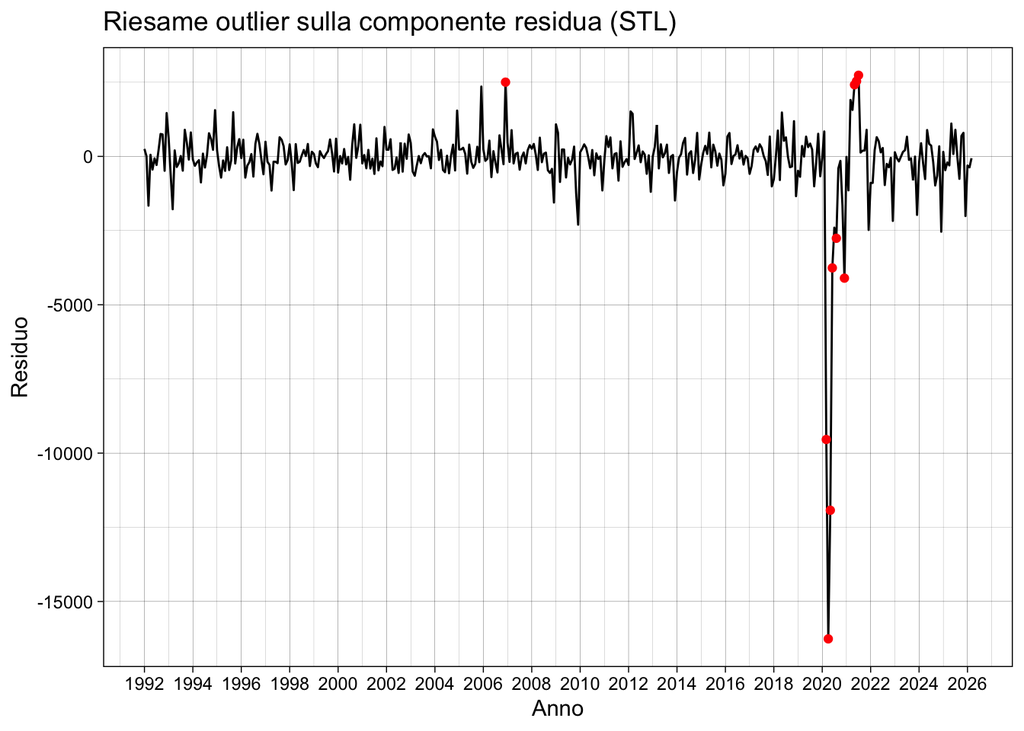

Riapplicando la procedura di identificazione degli outlier sulla componente residua (Serie ripulita da trend e stagionalità) della decomposizione STL notiamo che vi sono poche osservazioni anomale rispetto al primo esame. Queste ultime sono interpretabili come anomalie. Questo, in fase di modellazione, potrebbe giustificare il trattamento del periodo COVID tramite dummy.

### 3.5 Stazionarietà e Differenziazione

Una serie stazionaria guardandola in qualsiasi finestra temporale dovrebbe apparire statisticamente simile,non presenta pattern prevedibili nel lungo periodo e oscilla intorno a un livello fisso con varianza costante. In pratica le sua prorprietà statistiche non dipendono dal momento in cui la osserviamo.

Anche dopo la correzione per l’inflazione, la serie reale non si presenta stazionaria. Come osservato nel confronto grafico permangono sia la fluttuazione stagionale sia un trend di fondo. Per renderla stazionaria ricorriamo alla differenziazione che sostituisce ad ogni valore la sua variazione rispetto ad un valore precedente. Una eventuale differenza prima rimuoverà il trend residuo.

```r
nsdiffs(Vendite_Reali_CPI2)   #restituisce il numero di differenze stagionali
```

```
## [1] 1
```

L’output ci suggeriesce $1$ differenza stagionale. La applichiamo

```r
Vendite_Reali_DIFFstag <- diff(Vendite_Reali_CPI2, lag = 12)
ndiffs(Vendite_Reali_DIFFstag)
```

```
## [1] 0
```

Restituendo $0$ la sola differenza stagionale rende già la serie stazionaria. Non serve alcuna differenza prima.

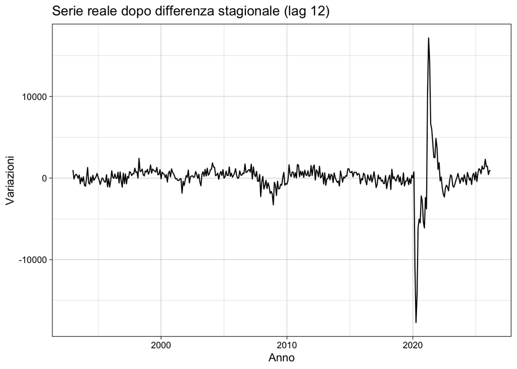

Dopo la differenza stagionale la serie ora oscilla attorno a un livello fisso pari a zero.Confrontando finestre temporali il comportamento appare omogeneo: la media resta costante e l’ampiezza delle fluttuazioni è sostanzialmente stabile lungo tutto l’arco temporale. Il “prevedibile” (trend e stagionalità) è stato rimosso e resta soltanto la componente irregolare. L’unica eccezione è il biennio 2020-2021, dove si osservano oscillazioni molto maggiori. Non si tratta però di una violazione strutturale della stazionarietà, bensì di un evento isolato come descritto in precedenza.

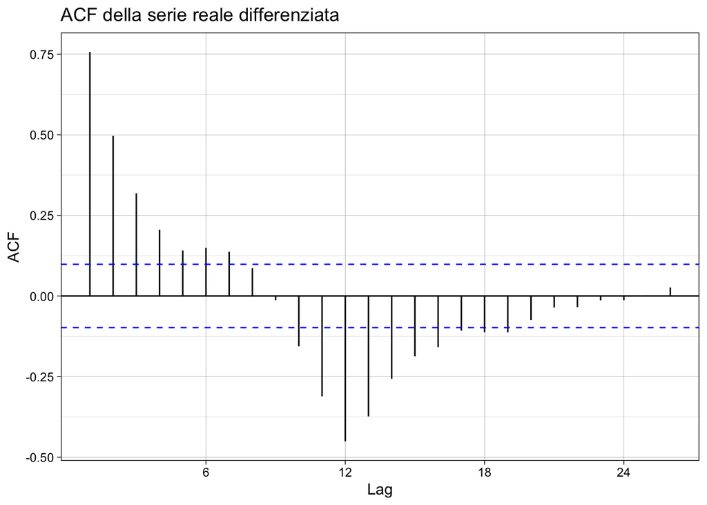

# 4. Confronto con serie analoga

Per rendere sensato il confronto tra due serie storiche è opportuno rimuovere trend e stagionalità, così da evitare il problema della correlazione spuria (serie che sembrano correlate solo perché crescono entrambe nel tempo). Affianchiamo all’abbigliamento una seconda serie ovvero:

**Retail Sales: Beer, Wine, and Liquor Stores** (`MRTSSM4453USN`): vendite al dettaglio mensili di birra, vino e liquori, in milioni di dollari. Dato che è un mercato con dinamiche proprie, ci aspettiamo che sia scollegato dall’abbigliamento.

Anche questa serie viene deflazionata con lo stesso CPI e la stessa base (`cpi_base`) usati per l’abbigliamento, così il confronto avviene interamente su valori reali.

```r
dati3 <- read.csv("MRTSSM4453USN.csv")
Liquor_nom <- ts(as.numeric(dati3$MRTSSM4453USN), start=c(1992,1), frequency=12)
fin_liquor <- ts.intersect(Liquor_nom, cpi_ts)
Liquor_Reali_pre <- (fin_liquor[,"Liquor_nom"] / fin_liquor[,"cpi_ts"]) * cpi_base
```

```
## [1] "Length of time series:"
## [1] 411
## [1] "-------------------------"
## [1] "Number of Missing Values:"
## [1] 1
## [1] "-------------------------"
## [1] "Percentage of Missing Values:"
## [1] "0.243%"
## [1] "-------------------------"
## [1] "Number of Gaps:"
## [1] 1
## [1] "-------------------------"
## [1] "Average Gap Size:"
## [1] 1
## [1] "-------------------------"
```

[output cut: 17 more lines]

Dato che è presente un NA allora usiamo come metodo di imputazione l’interpolazione lineare

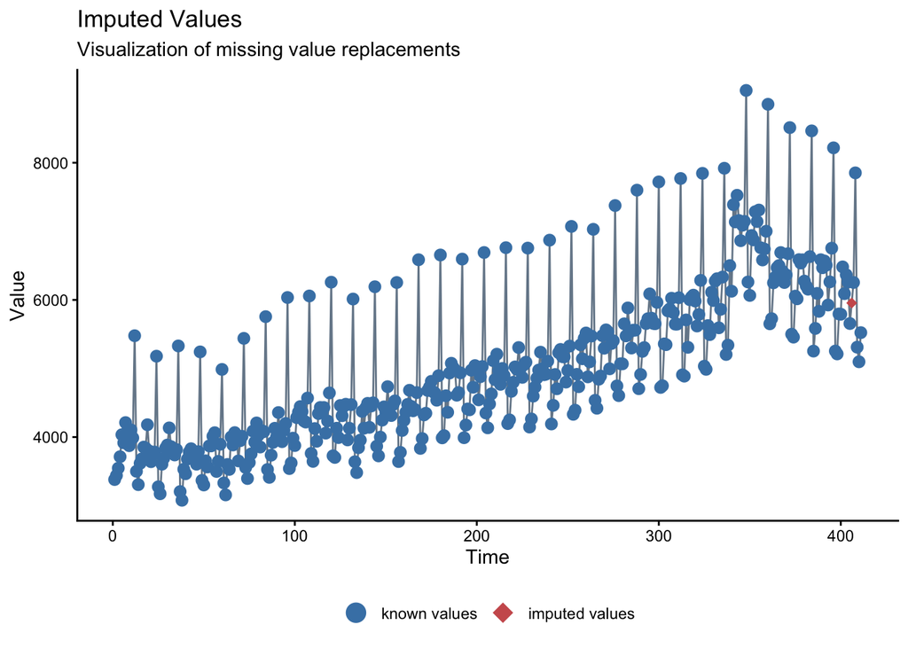

### 4.1 Confronto grafico

I due settori hanno ordini di grandezza molto diversi,di conseguenza li rappresentiamo in pannelli con scala verticale indipendente.

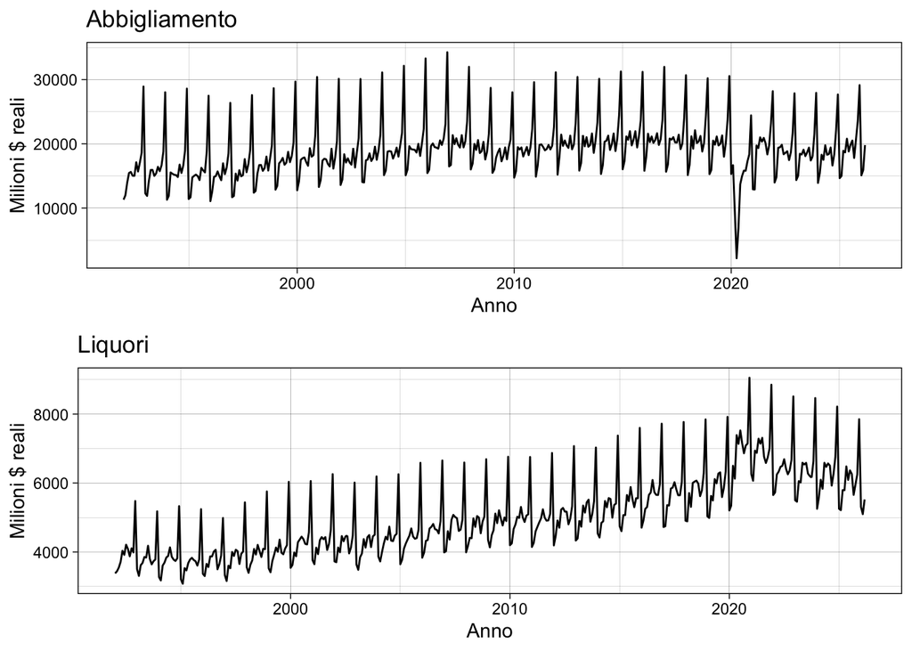

Dal confronto notiamo che l’abbigliamento ha una forte stagionalità con picco a dicembre e un crollo nel 2020. Liquor invece durante il Covid non crolla ma cresce difatti con la chiusura di bar e ristoranti l’alcool è stato prevalentemente consumato nelle abitazioni. Già visivamente i due settori si comportano in modo diverso.

### 4.2 Correlazione al netto di trend e stagionalità

Utilizziamo come prima la decomposizione STL robusta. Rimuoviamo trend e stagionalità.

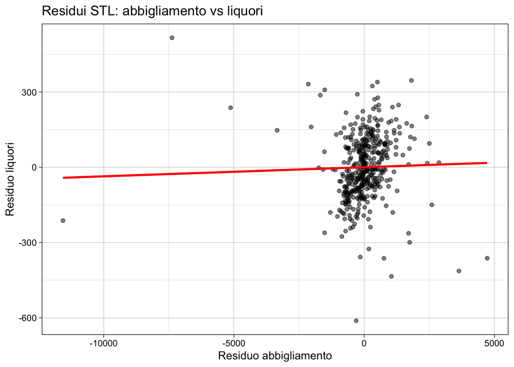

```r
cor(as.numeric(rem_abbigliamento), as.numeric(rem_liquor))
```

```
## [1] 0.02871806
```

La correlazione è leggermente positiva ma molto debole. Il grafico mostra che, rispetto agli shock imprevisti, i due settori sono in larga parte disaccoppiati nel contemporaneo, la reazione alle anomalie nello stesso istante è praticamente indipendente. Questo non esclude però legami a ritardi diversi da zero, che verifichiamo di seguito con la CCF.

Aggiungiamo infine la **cross-correlation function (CCF)**, per verificare se esista un qualche legame a ritardi diversi da zero.

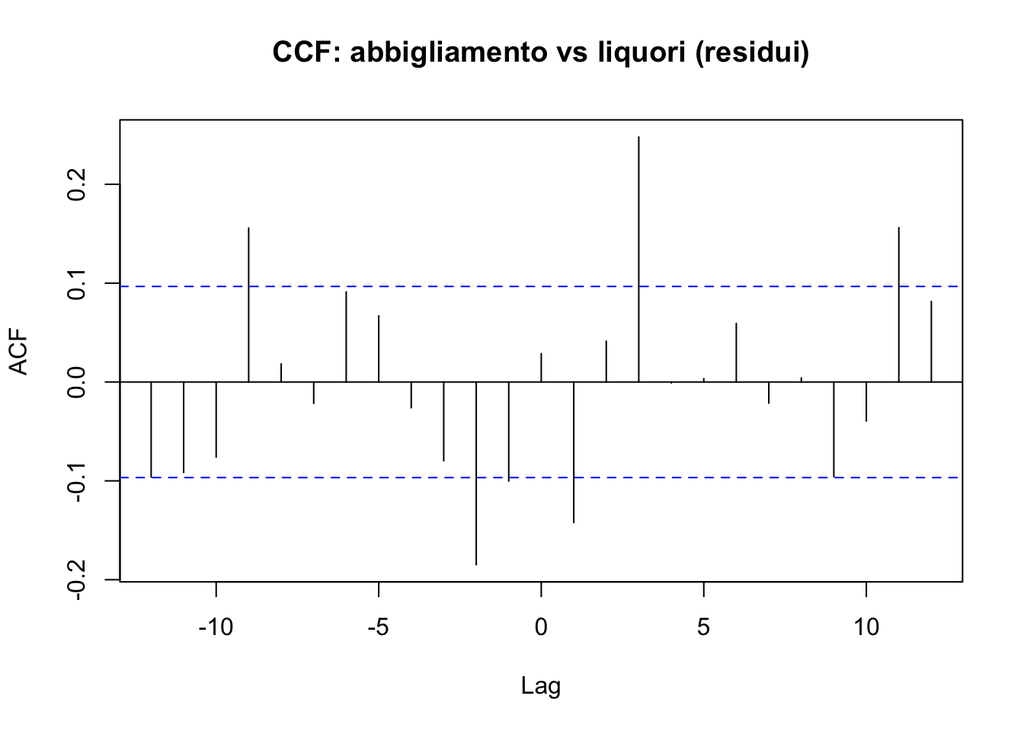

La CCF presenta alcuni picchi significativi (oltre le bande di confidenza) pertanto, non possiamo dire che i settori seguano logiche completamente autonome, ma possiamo dire che le loro interazioni si manifestano non in modo simultaneo bensì differite nel tempo.

# 5. Modellazione e previsione

### 5.1 Metodi Benchmark

I metodi benchmark rappresentano gli standard di riferimento più semplici per l’elaborazione delle previsioni. Nonostante lo sviluppo di modelli più avanzati e potenzialmente più performanti, i benchmark rimangono un termine di paragone per valutarne l’effettiva efficacia.

#### 5.1.1 Average

Le previsioni dei valori futuri sono uguali alla media delle osservazioni passate.

```
##          Point Forecast    Lo 80    Hi 80    Lo 95    Hi 95
## Apr 2026       18901.59 13388.85 24414.33 10459.25 27343.94
## May 2026       18901.59 13388.85 24414.33 10459.25 27343.94
## Jun 2026       18901.59 13388.85 24414.33 10459.25 27343.94
## Jul 2026       18901.59 13388.85 24414.33 10459.25 27343.94
## Aug 2026       18901.59 13388.85 24414.33 10459.25 27343.94
## Sep 2026       18901.59 13388.85 24414.33 10459.25 27343.94
## Oct 2026       18901.59 13388.85 24414.33 10459.25 27343.94
## Nov 2026       18901.59 13388.85 24414.33 10459.25 27343.94
## Dec 2026       18901.59 13388.85 24414.33 10459.25 27343.94
## Jan 2027       18901.59 13388.85 24414.33 10459.25 27343.94
## Feb 2027       18901.59 13388.85 24414.33 10459.25 27343.94
## Mar 2027       18901.59 13388.85 24414.33 10459.25 27343.94
```

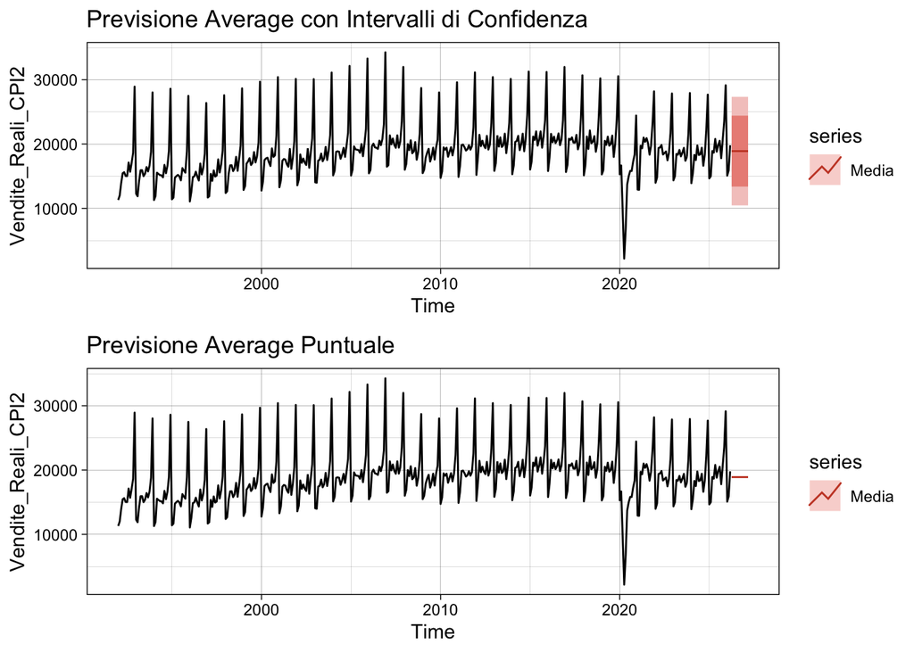

#### 5.1.2 Naive

Tutte le previsioni assumano il valore dell’ultima osservazione registrata

```
##          Point Forecast      Lo 80    Hi 80      Lo 95    Hi 95
## Apr 2026          19806 12932.6711 26679.33   9294.151 30317.85
## May 2026          19806 10085.6451 29526.35   4940.000 34672.00
## Jun 2026          19806  7901.0451 31710.95   1598.943 38013.06
## Jul 2026          19806  6059.3422 33552.66  -1217.699 40829.70
## Aug 2026          19806  4436.7694 35175.23  -3699.210 43311.21
## Sep 2026          19806  2969.8514 36642.15  -5942.667 45554.67
## Oct 2026          19806  1620.8811 37991.12  -8005.739 47617.74
## Nov 2026          19806   365.2901 39246.71  -9926.000 49538.00
## Dec 2026          19806  -813.9867 40425.99 -11729.548 51341.55
## Jan 2027          19806 -1929.3744 41541.37 -13435.387 53047.39
## Feb 2027          19806 -2990.2530 42602.25 -15057.860 54669.86
## Mar 2027          19806 -4003.9097 43615.91 -16608.115 56220.11
```

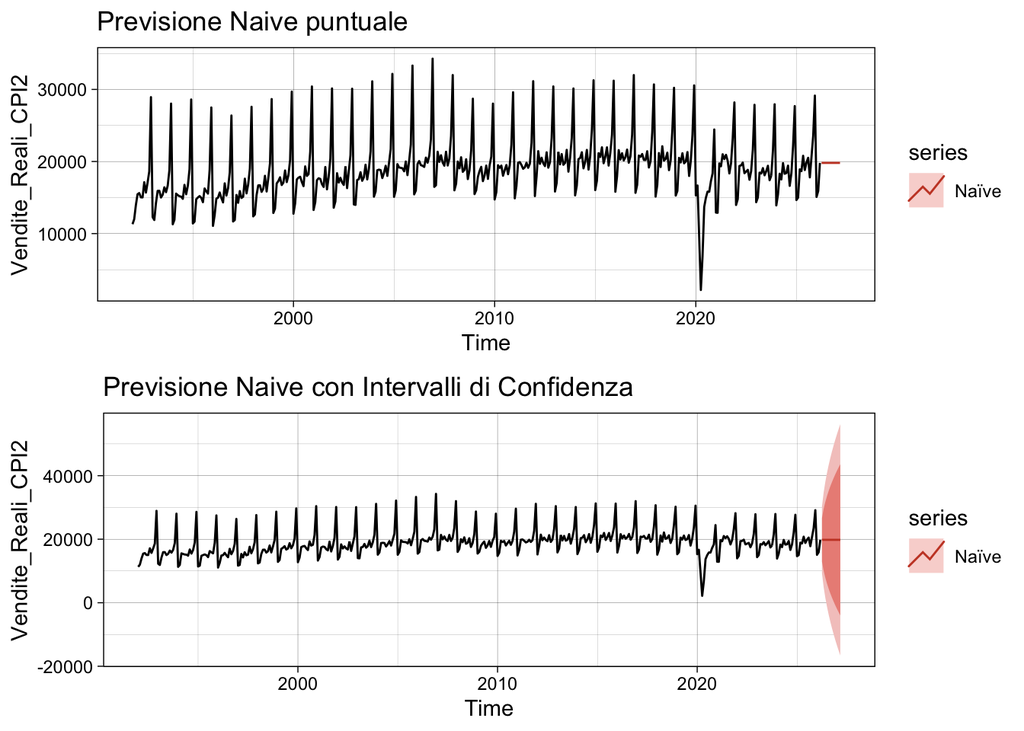

#### 5.1.3 Seasonal Naive

Estende il metodo Naive al caso di serie stagionali: ogni previsione viene impostata pari all’ultimo valore osservato nella stessa stagione, anziché all’ultima osservazione disponibile.

```
##          Point Forecast    Lo 80    Hi 80    Lo 95    Hi 95
## Apr 2026       18661.24 15925.84 21396.63 14477.81 22844.66
## May 2026       20792.84 18057.45 23528.24 16609.42 24976.27
## Jun 2026       18815.00 16079.60 21550.39 14631.57 22998.42
## Jul 2026       19859.92 17124.53 22595.32 15676.50 24043.35
## Aug 2026       20513.45 17778.06 23248.85 16330.03 24696.88
## Sep 2026       17798.77 15063.37 20534.16 13615.34 21982.19
## Oct 2026       20670.00 17934.61 23405.39 16486.57 24853.42
## Nov 2026       23541.23 20805.84 26276.63 19357.81 27724.66
## Dec 2026       29141.54 26406.14 31876.93 24958.11 33324.96
## Jan 2027       15086.66 12351.26 17822.05 10903.23 19270.08
## Feb 2027       15911.18 13175.78 18646.57 11727.75 20094.60
## Mar 2027       19806.00 17070.61 22541.39 15622.58 23989.42
```

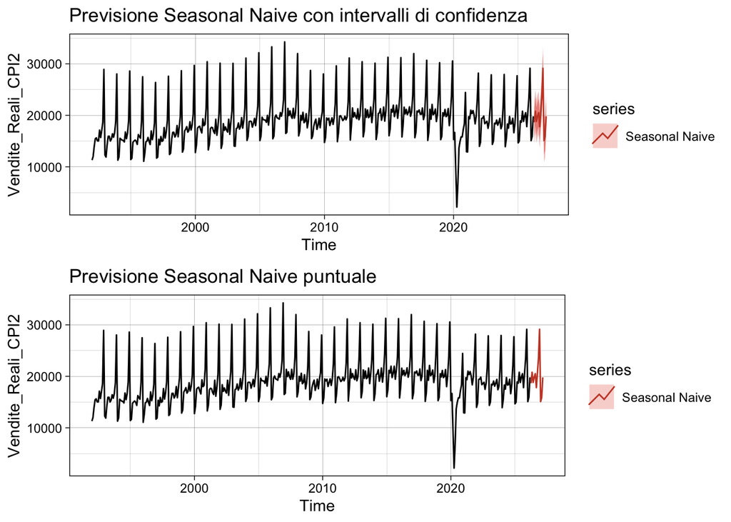

#### 5.1.4 Drift

Il Drift method permette alle previsioni di crescere nel tempo. Il drift è la variazione media osservata sulla base delle informazioni passate (variazione nel tempo).

```
##          Point Forecast      Lo 80    Hi 80      Lo 95    Hi 95
## Apr 2026       19826.74 12936.6774 26716.80   9289.299 30364.18
## May 2026       19847.48 10091.6129 29603.35   4927.169 34767.79
## Jun 2026       19868.22  7905.2798 31831.16   1572.483 38163.95
## Jul 2026       19888.96  6058.6329 33719.28  -1262.699 41040.62
## Aug 2026       19909.70  4428.2604 35391.13  -3767.117 43586.51
## Sep 2026       19930.44  2950.9520 36909.92  -6037.444 45898.32
## Oct 2026       19951.18  1589.2066 38313.15  -8131.033 48033.39
## Nov 2026       19971.92   318.6217 39625.21 -10085.204 50029.04
## Dec 2026       19992.66  -877.7309 40863.04 -11925.846 51911.16
## Jan 2027       20013.40 -2012.1604 42038.95 -13671.785 53698.58
## Feb 2027       20034.13 -3093.9472 43162.22 -15337.214 55405.48
## Mar 2027       20054.87 -4130.2919 44240.04 -16933.145 57042.89
```

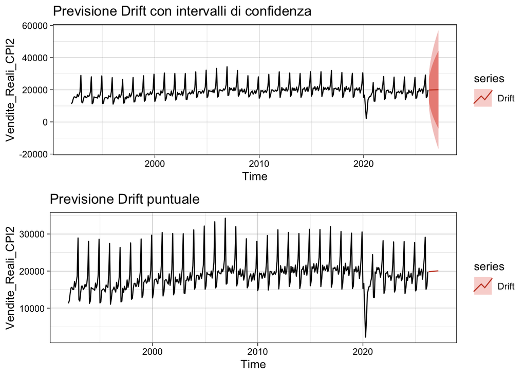

### 5.2 Previsione con decomposizione STL

Di per se la decomposizioen STL non è un metodo di previsione. La previsione mediante STL è possibile quando noi isoliamo la parte strutturale (trend e stagionalità) per proiettarle nel futuro tramite opportuni modelli.

```
##          Point Forecast    Lo 80    Hi 80     Lo 95    Hi 95
## Apr 2026       18566.45 17325.79 19807.11 16669.019 20463.87
## May 2026       20393.31 18636.61 22150.00 17706.675 23079.94
## Jun 2026       19912.53 17758.42 22066.64 16618.098 23206.95
## Jul 2026       20470.61 17980.25 22960.98 16661.932 24279.29
## Aug 2026       21031.85 18244.18 23819.52 16768.472 25295.22
## Sep 2026       19000.09 15942.68 22057.51 14324.177 23676.01
## Oct 2026       20589.52 17283.17 23895.88 15532.890 25646.16
## Nov 2026       23731.66 20192.78 27270.53 18319.411 29143.90
## Dec 2026       29632.94 25874.90 33390.97 23885.520 35380.35
## Jan 2027       15893.24 11927.20 19859.27  9827.701 21958.77
## Feb 2027       16669.99 12505.42 20834.55 10300.833 23039.14
## Mar 2027       19936.43 15581.52 24291.34 13276.170 26596.69
```

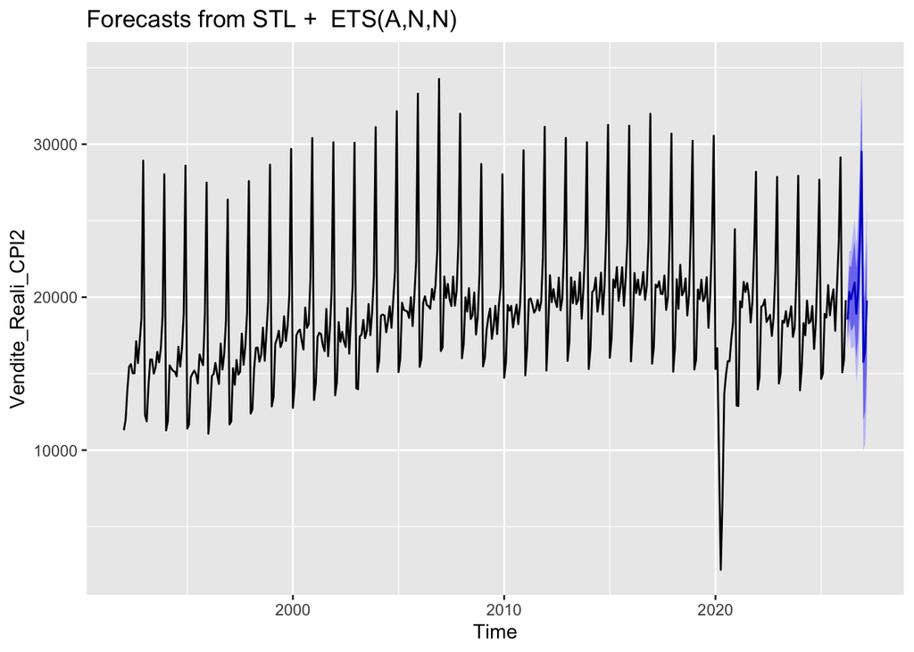

### 5.3 Regressione per serie storiche

La regressione per serie storiche modella la serie come combinazione di componenti osservabili. Costruiremo un modello lineare con 3 regressori/predittori:

**Trend** lineare (variabile tempo)

**Dummy stagionali** per i dodici mesi

**Dummy Covid** che isola il 2020. $R$ imposterà automaticamente Gennaio come Reference Group (Categoria di riferimento).

```r
tt <- time(Vendite_Reali_CPI2)
covid <- as.numeric(tt >= 2020 & tt < 2021)
```

```r
fit.reg <- tslm(Vendite_Reali_CPI2 ~ trend + season + covid)
summary(fit.reg)
```

```
##
## Call:
## tslm(formula = Vendite_Reali_CPI2 ~ trend + season + covid)
##
## Residuals:
##      Min       1Q   Median       3Q      Max
## -10965.8   -989.8    141.2   1014.4   6363.0
##
## Coefficients:
##               Estimate Std. Error t value Pr(>|t|)
## (Intercept) 12221.1866   300.5917  40.657   <2e-16 ***
## trend          10.3378     0.6731  15.359   <2e-16 ***
## season2       875.2330   379.1550   2.308   0.0215 *
## season3      4125.0107   379.1568  10.879   <2e-16 ***
## season4      3692.1796   381.9381   9.667   <2e-16 ***
## season5      4524.1875   381.9350  11.845   <2e-16 ***
## season6      3673.3135   381.9331   9.618   <2e-16 ***
## season7      3872.0199   381.9323  10.138   <2e-16 ***
## season8      5301.8568   381.9328  13.882   <2e-16 ***
## season9      3404.9624   381.9344   8.915   <2e-16 ***
## season10     4733.0238   381.9372  12.392   <2e-16 ***
## season11     7437.7722   381.9413  19.474   <2e-16 ***
## season12    15443.2715   381.9464  40.433   <2e-16 ***
## covid       -6285.8096   474.2467 -13.254   <2e-16 ***
## ---
## Signif. codes:  0 '***' 0.001 '**' 0.01 '*' 0.05 '.' 0.1 ' ' 1
##
## Residual standard error: 1586 on 397 degrees of freedom
## Multiple R-squared:  0.8676, Adjusted R-squared:  0.8633
## F-statistic: 200.1 on 13 and 397 DF,  p-value: < 2.2e-16
```

Il coefficiente di `trend` è pari a circa **10,34** ed è altamente significativo. Al netto di stagionalità e Covid (a parità di mese e a parità di status Covid, ceteris paribus), la domanda reale di abbigliamento cresce in media di 10,34 milioni di dollari al mese, una crescita di fondo positiva ma leggera.

Tutte le stime per le 11 dummy stagionali risultano significative.

Gennaio (categoria di riferimento assorbita dall’intercetta) è il mese con i volumi minimi e ogni altro mese registra volumi superiori. Lo scostamento fino a **dicembre** per esempio è pari a `season12` ≈ +15443 (rispetto a gennaio), **novembre** (`season11` ≈ +7438): sono i due mesi che staccano nettamente tutti gli altri (è la conferma numerica del picco natalizio già individuato). Il coefficiente `covid` è pari a circa **−6286** ed è altamente significativo. Ne deduciamo che durante il 2020 i volumi reali sono stati in media inferiori di circa 6286 milioni di dollari: la dummy cattura così il livello medio del crollo annuo. Il modello presenta un $R^2_{adjusted}$ di **0,863** (riusciamo quindi a spiegare circa l’86% della variabilità delle vendite reali corrette per inflazione). Dal test F deduciamo che non preferiamo il modello nullo (modello con sola intercetta).

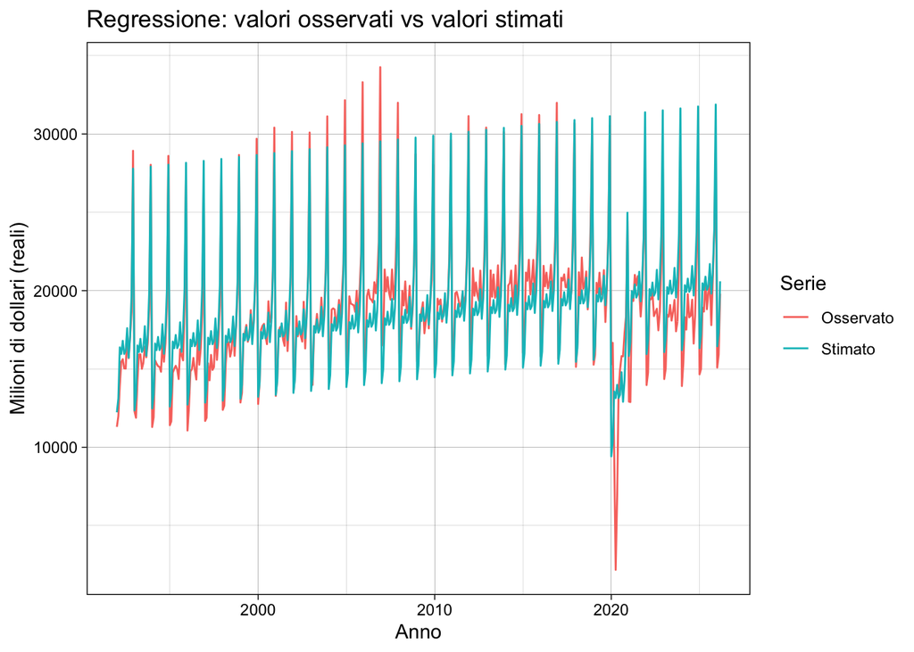

Il confronto tra serie osservata e valori stimati mostra quanto il modello di regressione sole componenti deterministiche riesca a riprodurre l’andamento reale.La dummy Covid permette al modello di adattarsi al crollo del 2020 senza che questo distorca la stima del trend e dei coefficienti stagionali. Gli eventuali scostamenti tra le due curve sono la parte non catturata dalla specificazione deterministica (residui).